# HW1

Edward Zhang

1/14/2022

## Case 1: Audience Size

### 2.1 Data Preparation

#### i. Selecting variables of Interest

```r
surveyResults <- read.csv('Survey_results_final.csv')
filtered <- surveyResults[, c(28, 29, 30, 31, 32, 33, 10)]
newNames <- c('age', 'gender', 'education', 'income', 'sirius', 'wharton',
              'worktime')

for (idx in 1:7){
  names(filtered)[idx] <- newNames[idx]
}

realGender <- filtered[, 'education']
realEdu <- filtered[, 'gender']

filtered[, 'education'] <- realEdu
filtered[, 'gender'] <- realGender
```

#### ii. Handling incorrectly filled data

The initial dataset seemed to have education and gender values that were swapped. This was resolved by simply swapping their values.

```r
  cnt <- 1
  for (elt in filtered$wharton){
    if (elt == "Yes"){
      filtered[cnt, "sirius"] <- "Yes"
    }
    cnt <- cnt + 1
  }
```

Furthermore, I went through all the affirmative answers for listening to Wharton and made sure that its corresponding response to listening to Sirius was also affirmative because Wharton’s show is literally broadcast on the Sirius channel.

```r
  filtered[1008, "age"] <- "18"
  filtered[664, "age"] <- "22"
  filtered[1535, "age"] <- "27"
  filtered <- filtered[-c(886, 479, 663,
                          1018, 1251, 1261, 1386, 1643,
                          100, 497, 764, 784, 963,
                          261, 559, 578,
                          856, 1481),]

  filtered$age <- as.numeric(filtered$age)
```

The column of Age appears to be a character string which does not really make any sense. In sorting it, we find that there are 4 incorrect entries. Since there are a total of 1764 data points to work with, I will simply tossed out two of those bad entries and corrected the other two (eighteen(18) -> 18, 27’ -> 27).

Someone also reported to be 223, so I made then 22. Once that was done, I converted that column into numerical typings.

Looking at the gender results, six additional people left that field blank, so I removed them from the dataset.

Looking at education results, a couple people didn’t actually select an option, but we’ll keep that for now.

Looking at income, five people left that field blank, so they were removed.

Looking at sirius listenership, three people left it blank. Since they also did not listen to wharton, we cannot be sure if they listened to sirius or not. Thus they were removed as well.

Looking at wharton’s listenership, two people left it blank, and based on their sirius listenership, we cannot determine whether or not they listened to wharton or not.

There were no issues with the worktime field as that is processed by MTurk.

#### iii. Summary

```
##       age          gender           education            income
##  Min.   : 4.0   Length:1746        Length:1746        Length:1746
##  1st Qu.:23.0   Class :character   Class :character   Class :character
##  Median :28.0   Mode  :character   Mode  :character   Mode  :character
##  Mean   :30.4
##  3rd Qu.:34.0
##  Max.   :76.0
##     sirius            wharton             worktime
##  Length:1746        Length:1746        Min.   :120
##  Class :character   Class :character   1st Qu.:120
##  Mode  :character   Mode  :character   Median :120
##                                        Mean   :120
##                                        3rd Qu.:120
##                                        Max.   :120
```

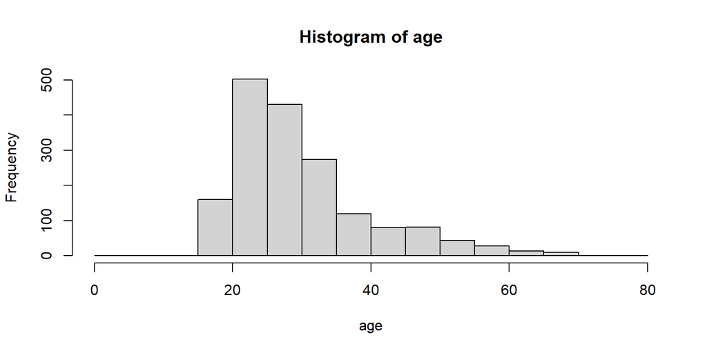

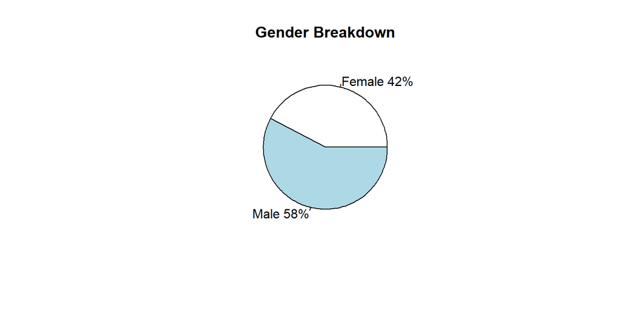

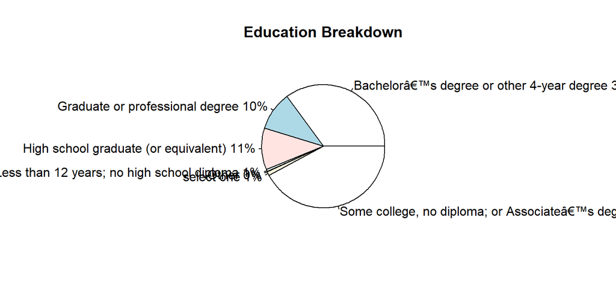

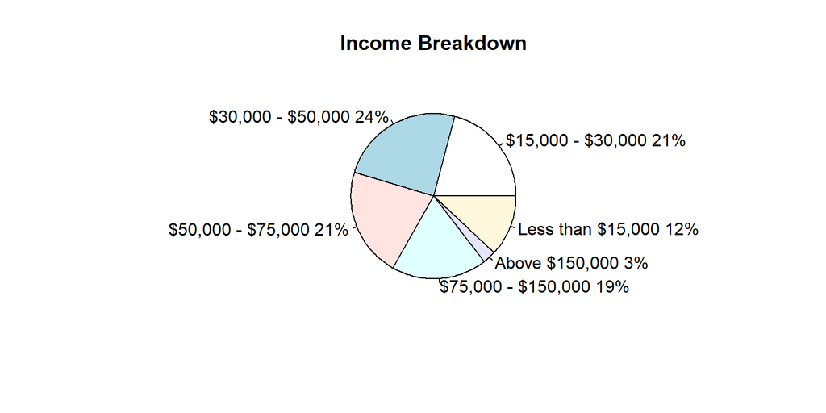

The respondants to this survey seem to consist of mainly young people with low to moderate levels of income. There are slightly more men than women that responded, and very few people that responded had any education beyond that of a Bachelor’s degree. This generally paints our pool of respondents as mostly college aged students and young adults in the process of transitioning into the workforce.

### 2.2 Sample Properties

#### Comparison to General US Population

50.8% of the US population is female which contrasts with the 58 - 42 Male - Female split shown in our sample pool. Our sample is much younger than the US population at large, with a major under representation of the 60-69 year old population in favor of the 20 to 40 year old portion of the population.

However, within that 20-40 year old portion of our sample size (in which the majority of our respondents came from), our sample reflects the educational levels of the general US populace as of 2019 with a slight over representation within the grouping of holders or graduate/professional degrees.

In terms of income, our MTurk sample averages a lower general income level compared to the percentage distribution of household income in the US as of 2020, with only 3% of our sample making over 150K per year where as over 18% of American households make 150K or more per year. This discrepancy can likely be explained by the notion that people with lower levels of income would be more predisposed to embrace gig work like that of MTurk.

Thus, our sample is not a perfect representation of the general US population. More-so, our sample more specifically reflects a more educated and male, but lower income portion of the US population.

#### Comparison to the MTurk Population

MTurk’s userbase skews even more female than the general US population, with roughly 58% of its userbase being female, clashing even more with our sample’s male majority. However, in terms of age, our sample is much more in line with the distribution of MTurker ages, though our sample remains slightly younger than MTurk as a whole.

In terms of education, MTurk’s general education level is fairly well reflected in the education levels of the our sample, with roughly 91% of the general MTurk population having had at least some college experience as opposed to the 88% found in our research sample.

Regarding income, our sample’s income levels reflect the trends found in the general MTurk population very well, though it still under performs MTurk by a little. This might coincide with the fact that our sample was generally younger than the overall MTurk population.

Overall, our sample is much more reflective of the MTurk population than it is of the general US population, to the point where it might even be within the margin of error for being considered as a representative random sample of the MTurk population. Though while it may be functionally equivalent to being a random sample of the MTurk population, it is likely that the pricing of this task was what drove the general age and income of its respondents downward.

Sources:

Hanson, Melanie. “Education Attainment Statistics” EducationData.org, November 22, 2021, https://educationdata.org/education-attainment-statistics

“Mechancial Turkers: Young, Well-Educated and Frequent Users.” Pew Research Center: Internet, Science & Tech, Pew Research Center, 30 May 2020, https://www.pewresearch.org/internet/2016/07/11/turkers-in-this-canvassing-young-well-educated-and-frequent-users/.

Moss, Aaron, and Leib Litman. “Demographics of People on Amazon Mechanical Turk.” CloudResearch, 10 Aug. 2020, https://www.cloudresearch.com/resources/blog/who-uses-amazon-mturk-2020-demographics/.

U.S. Census Bureau 2019. QuickFacts

“U.S. Income Distribution 2019.” Statista, 21 Sept. 2021, https://www.statista.com/statistics/203183/percentage-distribution-of-household-income-in-the-us/.

### 2.3 Final Estimate

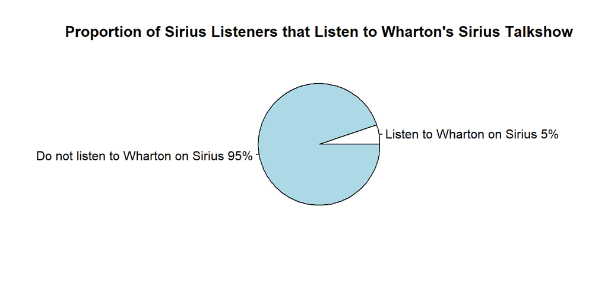

```r
#There are are roughly 51.6 Million SiriusXM
#In order to listen to the Wharton show, one MUST be listening on SiriusXM
#Thus, the percentage of SiriusXM listeners that listen to Wharton should be
#our overall percentage.

idx = 1

yesCnt = 0
noCnt = 0

for (x in filtered$sirius){
    if (x == "Yes"){
      if (filtered$wharton[idx] == "Yes"){
        yesCnt <- yesCnt + 1
      } else {
        noCnt <- noCnt + 1
      }
    }
    idx <- idx + 1
}

listenerBreakdown <- c(yesCnt, noCnt)
labels <- c("Listen to Wharton on Sirius", "Do not listen to Wharton on Sirius")

pct <- round(listenerBreakdown/sum(listenerBreakdown)*100)
labels <- paste(labels, pct) # add percents to labels
labels <- paste(labels,"%",sep="") # ad % to labels
pie(listenerBreakdown, labels = labels, main= "Proportion of Sirius Listeners that Listen to Wharton's Sirius Talkshow")
```

```r
.05 * 51.6
```

```
## [1] 2.58
```

Based on our results, 5% of SiriusXM listeners listen to the Wharton show, meaning that roughly 2.58 million people listen to Wharton’s show.